# Using Text Mining Analysis to Make Suggestions to Improve the Rating of a Poorly-Rated Business

STQD6324 Data Management - Assignment 1

Ng Chin Wen

2025-05-11

## 1. Introduction

### -

The dataset was sourced from Yelp (Yelp (n.d.)). In the initial compressed file is another .tar file which contains the dataset. The yelp_dataset.tar file contains 5 JSON files; yelp_academic_dataset_business.json, yelp_academic_dataset_checkin.json, yelp_academic_dataset_tip.json, yelp_academic_dataset_user.json, yelp_academic_dataset_review.json, henceforth will be referred to as business.json, checkin.json tip.json, user.json, review.json. However, the main JSON files of concern are business.json, user.json, and review.json.

The business.json contains information related to the business including its location and some of its attributes. The reviews.json contains the actual text of the reviews and its associated rating and other information. The users.json contains information about Yelp’s userbase including their friend network along with associated information about votes and compliments submitted to that user by other users.

The files not used in this analysis are described as below: The checkin.json contains businesses and a list of timestamps of each checkin; check-ins are a way for people to keep track of places they’ve visited to their friend network. The tip.json is similar to review.json, but instead of a more involved text review, a tip is just more similar to one-liners to convey a quick message.

Hive was used to store the large files (difficult or impossible to store) and data exploration. Python was used to connect Hive to R in an easy way and to have access to Python’s functionality. RStudio was used for pre-processing, data analysis and visualisation. R Markdown was used since its has more functionality and ease-of-use as a text editor compared to Jupyter Notebook such as copy pasting images directly from clipboard while having options to produce a HTML document or a Github Document.

### 1.1 Objectives

- Use the Hadoop ecosystem to store, query and access the database into R.
- Identify top-rated businesses - determine which businesses receive the highest ratings overall, in specific categories (e.g., restaurants, cafes, hair salons), or in a location.
- Analyze customer sentiment based on Yelp reviews using text-based analysis, and make recommendations based on that.

### 1.2 Summary of business.json

Below is a summary of the original columns and the type of data that was stored inside. For columns that were JSON object structures (struct), they had to be expanded out as well.

| Name | Description | Data type |
| --- | --- | --- |
| business_id | A 22-character string containing a uinque ID for the business - used to connect reviews, category | string |
| name | The name of the business | string |
| address | The address of the business | string |
| city | The city where the business is located | string |
| state | The state code where the business is located | string |
| postal code | The postal code where the business is located | string |
| latitude | The latitude of where the business is located | float |
| longitude | The longitude of where the business is located | float |
| stars | Average rating, rounded to half-stars | float |
| review_count | total number of reviews | float |
| is_open | Whether is it closed (0) or open (1) | boolean |
| attributes | Has several logical variables related | struct |
| categories | Related to what category the business is | string array |
| hours | Opening hours for each day of the week | struct |

### 1.3 Summary of review.json

| Name | Description | Data type |
| --- | --- | --- |
| review_id | 22-character unique review ID | string |
| user_id | ID for the user that wrote the review - maps to user.json | string |
| business_id | ID of the business the review is for - maps to business.json | string |
| stars | Rating out of 5 | integer |
| date | Date the review was submitted | string |
| text | The actual review text itself | string |
| useful | Number of ‘useful’ votes received from other users | integer |
| funny | Number of ‘funny’ votes received from other users | integer |
| cool | Number of ‘cool’ votes received from other users | integer |

## 2. Data Storage and Set-Up

### 2.1 Data Storage Using Hadoop

Since reviews and users are very large (5GB and 3GB respectively), they cannot easily be manipulated in R or Python. Because of those files in particular, all JSON files were moved to the VirtualBox local folders using [WinSCP](https://winscp.net/eng/download.php). Then all the files were converted into Hive tables using Spark.

An example of a script using Spark.

```sql
## To be run in the Virtual Machine
from pyspark.sql import SparkSession

spark = SparkSession.builder \
    .appName("JSON Schema Viewer") \
    .getOrCreate()
df = spark.read.json("C:/Users/Documents/a_ncw/2manage/yelp_academic_dataset_user.json")
df.write.mode("overwrite").saveAsTable("yelp_user")
```

For business.json, since it has some struct data types.

```sql
## To be run in the Virtual Machine
from pyspark.sql import SparkSession
from pyspark.sql.types import StructType
from pyspark.sql.functions import col, split, explode, trim

spark = SparkSession.builder \
    .appName("JSON to Hive") \
    .enableHiveSupport() \
    .getOrCreate()

df=spark.read.json("hdfs:///user/maria_dev/yelp/yelp_academic_dataset_business.json")
def flatten(schema,prefix=None):
    fields=[]
    for field in schema.fields:
        name = prefix + '.' + field.name if prefix else field.name
        dtype=field.dataType
        if isinstance(dtype, StructType):
            fields += flatten(dtype, prefix=name)
        else:
            fields.append(name)
    return fields
df.write.mode("overwrite").saveAsTable("yelp_business")
```

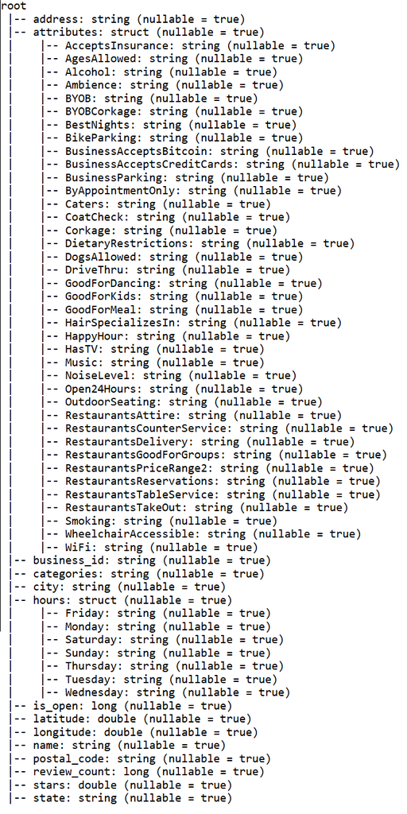

Another example of checkin’s schema when turning the checkin json to a hive table.

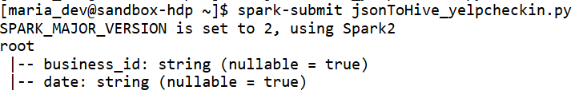

However, the JSON file for yelp_reviews’ text file kept overflowing into business_id or returning back blank. After reading around, \n newline for Hive causes it to split it into a new line. Thus, to avoid this, all in the text column for review.json was replaced by a space before it was converted to a Hive table.

```sql
## To be run in the Virtual Machine
from pyspark.sql import SparkSession
from pyspark.sql.functions import regexp_replace

spark = SparkSession.builder \
    .appName("JSON to Hive") \
    .enableHiveSupport() \
    .getOrCreate()

df_review = spark.read.json("hdfs:///user/maria_dev/yelp/yelp_academic_dataset_review.json")
df_review = df_review.withColumn("text",regexp_replace("text",r'\n',' '))

df_review.write.mode("overwrite").saveAsTable("yelp_review")
```

### 2.2 Setting up R

For my specific case, since I had made a conda environment made to the hadoop framework, the conda environment within R also has to be set to that.

```r
reticulate::use_condaenv(condaenv = "C:\\Users\\PC05\\anaconda3\\envs\\ukm_stqd6324",required = TRUE)
```

Then after that, comes importing all the libraries, setting up a connection can be made via python for Hive querying and R for any further pre-processing and visualisation. Overall, after the data has been properly converted to JSON to Hive table, the flow of the data is Apache Hive -> Python -> R.

```python
import pandas as pd
from impala.dbapi import connect

conn = connect(
    host='127.0.0.1',
    port=10000,
    user='maria_dev',
    database='default',
    auth_mechanism = 'PLAIN'
)
cursor = conn.cursor()

# A function was made to simplify converting Hive queries to pandas dataframes.
def to_pd(cursor):
  columns = [desc[0] for desc in cursor.description]
  data = cursor.fetchall()
  return pd.DataFrame(data, columns=columns)
```

When looking at all the databases stored in Hive, I uploaded the following tables. The names match the name of aforementioned JSON files described before. *yelp_business_category* is a table based on the ‘category’ column in yelp_business that was expanded and its comma-separated list of categories pulled out.

```python
cursor.execute('SHOW TABLES')
print(cursor.fetchall())
```

[output not shown]

#### Example of querying

This is the extended description for yelp_business.

```python
cursor.execute('DESCRIBE yelp_business')
print(cursor.fetchall())
```

[output not shown]

After that, when we look at the columns for yelp_review:

```python
cursor.execute('DESCRIBE yelp_review')
print(cursor.fetchall())
```

[output not shown]

When running `ANALYZE TABLE yelp_review COMPUTE STATISTICS;` in Ambari’s Hive’s Query Editor and clicking Explain, we see that the number of reviews is 6990280, matching the number of reviews as mentioned on the Yelp website.

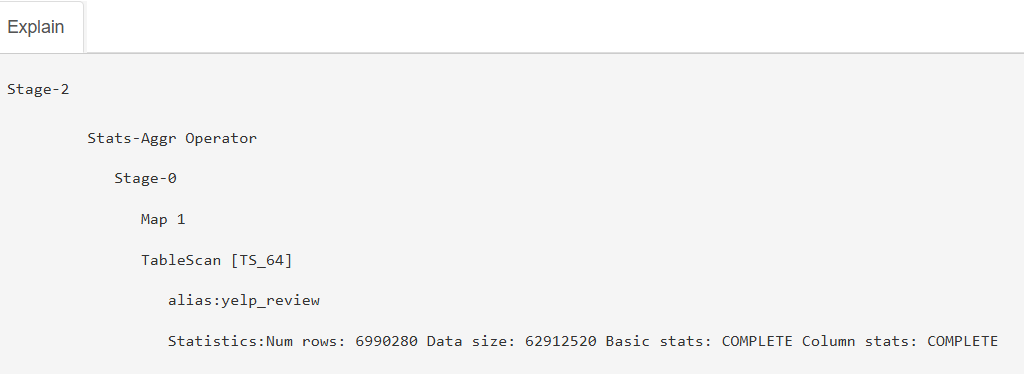

## 3.0 Choosing The Business

Packages used:

```r
library(ggplot2)
library(tidyverse)
```

### 3.1 Average star rating for all businesses

Out of all the stars rating, only nine values are possible since Yelp only displays it rounded to the nearest 0.5.

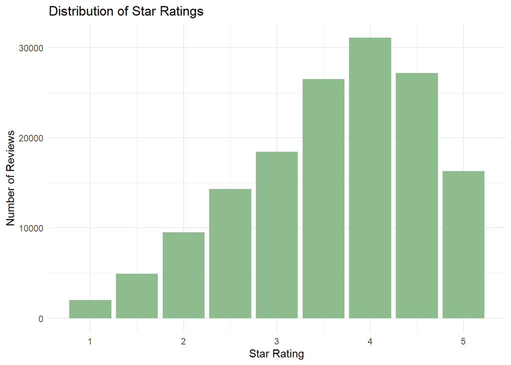

The x-axis is the rating, the left y-axis points to the frequency of the rating and the right y-axis is the average review count of a business with that rating. The green is number of businesses with that star rating and blue is average number of reviews for all businesses per star rating.

As can be seen, it does not follow the same proportion for the frequency. The top three highest average review counts are the same as the business count, but the two lowest are 1.0 and 5.0, which shows that most businesses with either a consistently high or low rating tend to have fewer reviews. This suggests that extreme ratings are pushed forward by a small number of reviews. As in, for example, if talking about it in a generalised overview, while businesses with a high 5-star rating would typically be seen as ‘better’ than those rated under 5, but in actuality, taking in account the difference in average review count vs rating, it could actually signify a business that is just niche or new instead of better.

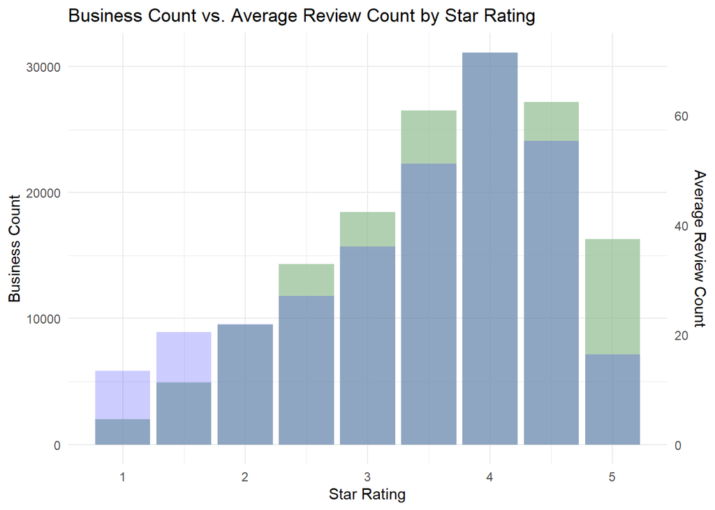

### 3.2 Distribution of categories

Looking at the category column, there are a total of 1310 unique values this could be. These columns are not distinct per business so a single business could belong to multiple categories.

```r
df<-reticulate::py$df
head(df)
```

```
##        category frequency
## 1   Restaurants     52268
## 2          Food     27781
## 3      Shopping     24395
## 4 Home Services     14356
## 5 Beauty & Spas     14292
## 6     Nightlife     12281
```

```r
df<-reticulate::py$df
mean(df$frequency) #average is 509.9863
```

```
## [1] 509.9863
```

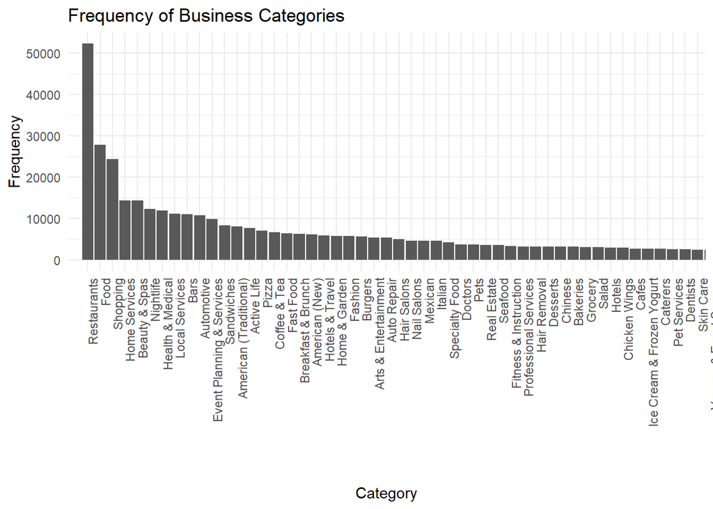

```r
ggplot(df, aes(x = reorder(category, -frequency), y = frequency)) +
  geom_bar(stat = "identity") +
  labs(
    title = "Frequency of Business Categories",
    x = "Category",
    y = "Frequency"
  ) +
  theme_minimal() +
  coord_cartesian(xlim=c(0,50)) +
  theme(axis.text.x = element_text(angle = 90, hjust = 1))
```

### 3.3 Distribution of review count

Looking at all businesses, it’s clear the review count is heavily right-skewed. The max is 7568, while the minimum number of reviews is only 5, yet the average number of reviews for any business in this dataset is only around 45.

```r
df<-reticulate::py$df
head(df)
```

[output not shown]

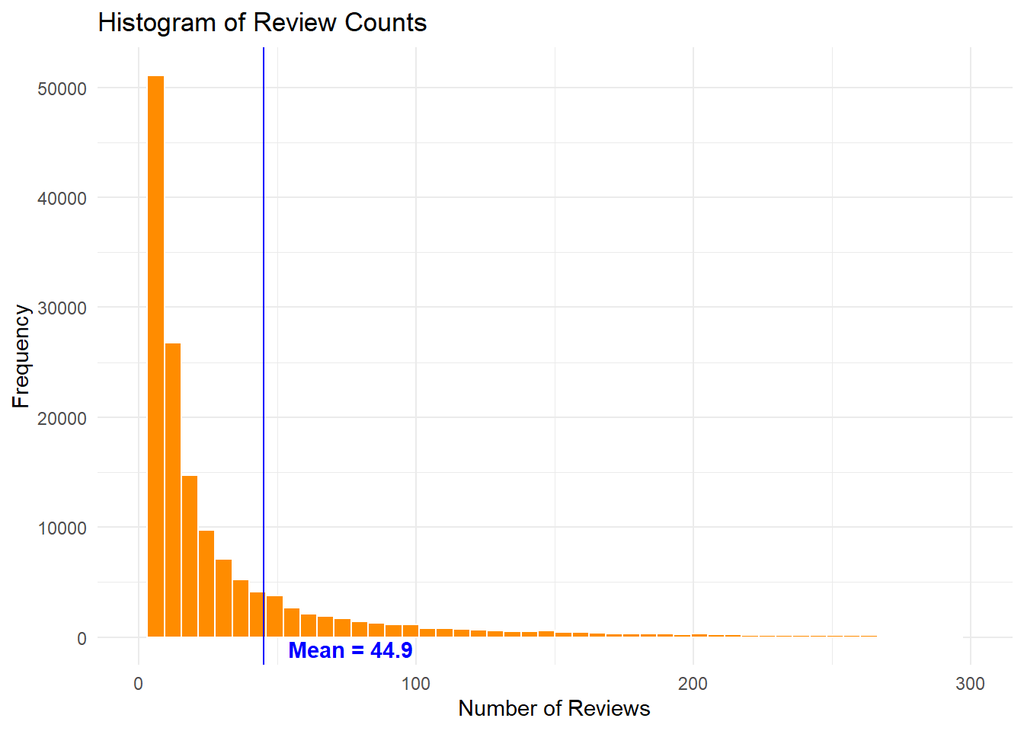

Amazingly, around a third of businesses on Yelp do not even hit 10 reviews

```r
sum(df$review_count < 10)
```

```
## [1] 51103
```

Overall, out of all the businesses that have at least 500 reviews are mostly from the US, namely cities such as Philadelphia, New Orleans, Nashville. This could be because they are well-known tourist destinations. Since these cities attract many visitors throughout the year, it most likely leads to a higher number of customers leaving reviews for businesses (restaurants, hotels, tourist attractions, etc.). However, take note that this Yelp dataset only covers 11 metropolitan areas, which is why other popular tourism cities like New York do not appear at all.

High foot traffic due to tourism and popular events (e.g., Mardi Gras in New Orleans or music festivals in Philadelphia and Nashville) could be contributing to the higher review count.

```r
df<-reticulate::py$df
df2 <- df %>% filter(review_count > 500)
gg<-sort(table(df2$city), decreasing = TRUE)[1:20]
gg
```

```
##
##     Philadelphia      New Orleans        Nashville            Tampa
##              276              249              128               98
##    Santa Barbara             Reno           Tucson      Saint Louis
##               89               88               62               60
##     Indianapolis Saint Petersburg            Boise Clearwater Beach
##               59               14               12               12
##       Clearwater    St Petersburg           Sparks           Goleta
##               11               11               10                7
##  King of Prussia         Metairie   St. Pete Beach          Dunedin
##                7                7                7                6
```

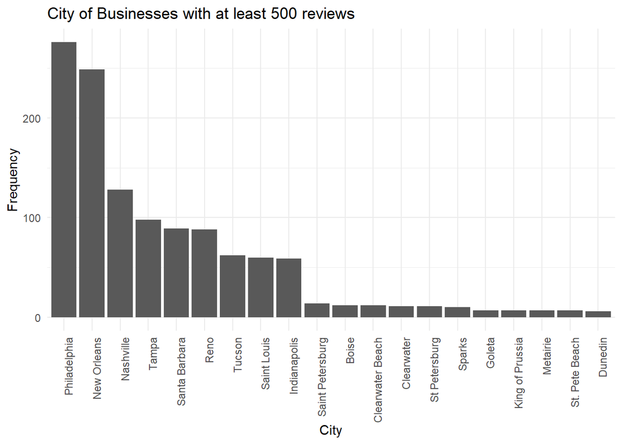

For New Orleans:

```r
df<-reticulate::py$df
head(df)
```

```
##          ybc.business_id  ybc.category
## 1 W4ZEKkva9HpAdZG88juwyQ          Bars
## 2 W4ZEKkva9HpAdZG88juwyQ     Nightlife
## 3 W4ZEKkva9HpAdZG88juwyQ Cocktail Bars
## 4 W4ZEKkva9HpAdZG88juwyQ         Cafes
## 5 W4ZEKkva9HpAdZG88juwyQ  Cajun/Creole
## 6 W4ZEKkva9HpAdZG88juwyQ      Barbeque
```

For those with a high review count in New Orleans, the categories associated with it is Cajun/Creole and Seafood, that is because those two cuisines are associated with New Orleans or Louisiana in general. In addition, Cajun/Creole is seafood-based.

```
##
##               Restaurants              Cajun/Creole                   Seafood
##                        82                        47                        36
##                 Nightlife                      Bars        Breakfast & Brunch
##                        26                        24                        24
##                      Food            American (New)                Sandwiches
##                        23                        22                        18
##                  Southern             Cocktail Bars    American (Traditional)
##                        18                        13                        11
##                     Cafes Event Planning & Services                    French
##                        11                         7                         6
##           Hotels & Travel                Vegetarian      Arts & Entertainment
##                         6                         6                         5
##              Coffee & Tea                  Desserts
##                         5                         5
```

For Nashville:

```r
df<-reticulate::py$df
head(df)
```

```
##          ybc.business_id              ybc.category
## 1 ORL4JE6tz3rJxVqkdKfegA     Venues & Event Spaces
## 2 ORL4JE6tz3rJxVqkdKfegA                  Day Spas
## 3 ORL4JE6tz3rJxVqkdKfegA                   Resorts
## 4 ORL4JE6tz3rJxVqkdKfegA                    Cinema
## 5 ORL4JE6tz3rJxVqkdKfegA                    Hotels
## 6 ORL4JE6tz3rJxVqkdKfegA Event Planning & Services
```

For those with a high review count in Nashville, the categories associated with it is similar to those in New Orleans with American and Southern food.

```
##
##               Restaurants                 Nightlife                      Bars
##                        34                        23                        22
##    American (Traditional)                  Southern            American (New)
##                        18                        17                        13
##                      Food        Breakfast & Brunch                  Barbeque
##                        13                        11                         6
##             Chicken Wings             Cocktail Bars                      Pubs
##                         6                         6                         6
##                Sandwiches      Arts & Entertainment                      Beer
##                         5                         3                         3
##                   Burgers                  Desserts Event Planning & Services
##                         3                         3                         3
##                   Lounges                   Mexican
##                         3                         3
```

For Philadelphia:

```r
df<-reticulate::py$df
head(df)
```

```
##          ybc.business_id ybc.category
## 1 vUrTGX_7HxqeoQ_6QCVz6g  Active Life
## 2 vUrTGX_7HxqeoQ_6QCVz6g     Lebanese
## 3 vUrTGX_7HxqeoQ_6QCVz6g Coffee & Tea
## 4 vUrTGX_7HxqeoQ_6QCVz6g  Restaurants
## 5 vUrTGX_7HxqeoQ_6QCVz6g    Nightlife
## 6 vUrTGX_7HxqeoQ_6QCVz6g         Food
```

For those with a high review count in Philadelphia, the categories associated with it is similar to New Orleans and Nashville, with the interesting difference being more Chinese/Asian and Italian food shops.

```
##
##            Restaurants              Nightlife                   Bars
##                     64                     21                     20
##     Breakfast & Brunch                   Food American (Traditional)
##                     19                     19                     18
##         American (New)             Sandwiches                Chinese
##                     17                     13                      9
##           Cheesesteaks                Seafood         Specialty Food
##                      8                      8                      8
##          Cocktail Bars           Coffee & Tea                Italian
##                      7                      7                      7
##             Vegetarian           Asian Fusion                  Cafes
##                      7                      6                      6
##                 Diners                   Beer                Burgers
##                      6                      5                      5
##               Japanese           Local Flavor            Steakhouses
##                      5                      5                      5
##         Wine & Spirits
##                      5
```

```r
a<-reticulate::py$df
```